# 全员地毯式风控画像｜统计推断、蒙特卡洛模拟与时序准回测

player_pair_stat / dealer_profit_stat_hourly 深度方法论报告

Author

Risk Analytics

Published

July 21, 2026

## 一、关键结构核实（必读，决定后续所有分析的正确解读方式）

```r
struct_check <- data.table(
  表名 = c("player_pair_stat", "player_pair_stat", "dealer_profit_stat_hourly", "dealer_profit_stat_hourly"),
  字段 = c("player_a", "player_b", "dealer_id", "player_id"),
  唯一值数量 = c(
    uniqueN(pps$player_a), uniqueN(pps$player_b),
    uniqueN(dph$dealer_id), uniqueN(dph$player_id)
  ),
  总行数 = c(nrow(pps), nrow(pps), nrow(dph), nrow(dph))
)
struct_check |> gt() |> tab_header(title = "关键ID字段唯一性核查")
```

关键ID字段唯一性核查

| 表名 | 字段 | 唯一值数量 | 总行数 |
| --- | --- | --- | --- |
| player_pair_stat | player_a | 289 | 100000 |
| player_pair_stat | player_b | 44433 | 100000 |
| dealer_profit_stat_hourly | dealer_id | 148 | 100000 |
| dealer_profit_stat_hourly | player_id | 26869 | 100000 |

### 2.1 为什么普通”加权风险分”不够严谨，要改用回归模型

之前的做法是人工设定权重加总，本质是”经验规则”。更严谨的做法是：**先建立”如果纯属随机同桌、理论上应该同桌几局”的统计期望模型（引力模型 Gravity Model）**，再看实际观测值偏离期望多远，这个偏离程度本身自带统计意义上的p值，而不是人为拍板的分数。

### 2.2 模型选择：泊松 vs 负二项（过度离散诊断）

```r
pps[, `:=`(log_a_rounds = log(player_a_rounds), log_b_rounds = log(player_b_rounds))]

poisson_model <- glm(same_round_count ~ log_a_rounds + log_b_rounds, data = pps, family = poisson())
overdispersion_ratio <- sum(residuals(poisson_model, type = "pearson")^2) / poisson_model$df.residual

cat(sprintf("泊松模型过度离散比率(Pearson卡方/自由度): %.2f\n", overdispersion_ratio))
```

```
泊松模型过度离散比率(Pearson卡方/自由度): 58.12
```

```r
cat(sprintf("判定: %s (经验准则 > 1.5 即视为显著过度离散，须改用负二项模型)\n",
            ifelse(overdispersion_ratio > 1.5, "存在显著过度离散，弃用泊松模型", "可用泊松模型")))
```

```
判定: 存在显著过度离散，弃用泊松模型 (经验准则 > 1.5 即视为显著过度离散，须改用负二项模型)
```

诊断结果确认存在过度离散，**改用负二项回归 (Negative Binomial GLM)** 重新拟合：

```r
nb_model <- glm.nb(same_round_count ~ log_a_rounds + log_b_rounds, data = pps)
summary(nb_model)
```

```
Call:
glm.nb(formula = same_round_count ~ log_a_rounds + log_b_rounds,
    data = pps, init.theta = 1.743317525, link = log)

Coefficients:
              Estimate Std. Error z value Pr(>|z|)
(Intercept)  -1.627611   0.017292  -94.12   <2e-16 ***
log_a_rounds  0.347736   0.001626  213.86   <2e-16 ***
log_b_rounds  0.314267   0.001185  265.11   <2e-16 ***
---
Signif. codes:  0 '***' 0.001 '**' 0.01 '*' 0.05 '.' 0.1 ' ' 1

(Dispersion parameter for Negative Binomial(1.7433) family taken to be 1)

    Null deviance: 229637  on 99999  degrees of freedom
Residual deviance: 104854  on 99997  degrees of freedom
AIC: 828990

Number of Fisher Scoring iterations: 1

              Theta:  1.74332
          Std. Err.:  0.00766

 2 x log-likelihood:  -828981.70300
```

```r
pps[, expected_nb := predict(nb_model, type = "response")]
theta <- nb_model$theta
pps[, p_raw := 1 - pnbinom(same_round_count - 1, size = theta, mu = expected_nb)]
```

### 2.3 多重比较校正（Benjamini-Hochberg FDR）

```r
pps[, p_fdr := p.adjust(p_raw, method = "BH")]
pps[, significant_raw := p_raw < 0.05]
pps[, significant_fdr := p_fdr < 0.05]

fdr_summary <- data.table(
  检验方式 = c("未校正 (p_raw < 0.05)", "FDR校正后 (p_fdr < 0.05)"),
  显著数量 = c(sum(pps$significant_raw), sum(pps$significant_fdr))
)
fdr_summary |> gt() |> tab_header(title = "多重比较校正前后对比")
```

多重比较校正前后对比

| 检验方式 | 显著数量 |
| --- | --- |
| 未校正 (p_raw < 0.05) | 5677 |
| FDR校正后 (p_fdr < 0.05) | 1055 |

```r
scorecard <- pps[order(-expected_nb, p_raw)][, .(
  搭档ID = player_b, 实际同桌局数 = same_round_count,
  模型期望局数 = round(expected_nb, 1),
  偏离倍数 = round(same_round_count / expected_nb, 2),
  原始p值 = signif(p_raw, 3), FDR校正后p值 = signif(p_fdr, 3),
  FDR显著 = significant_fdr
)][order(原始p值)]

datatable(scorecard, options = list(pageLength = 15, order = list(list(5, 'asc'))), rownames = FALSE) |>
  formatStyle("偏离倍数", background = styleColorBar(range(scorecard$偏离倍数), "#ffd6a5")) |>
  formatStyle("原始p值", backgroundColor = styleInterval(c(0.01, 0.05), c("#ff8b8b", "#ffe6a3", "white")))
```

| 搭档ID | 实际同桌局数 | 模型期望局数 | 偏离倍数 | 原始p值 | FDR校正后p值 | FDR显著 |
| --- | --- | --- | --- | --- | --- | --- |
| 149384716 | 6682 | 221.8 | 30.13 | 0 | 0 | True |
| 148405514 | 8088 | 218.7 | 36.98 | 0 | 0 | True |
| 142262798 | 5521 | 194.7 | 28.36 | 0 | 0 | True |
| 148408157 | 4912 | 193.9 | 25.33 | 0 | 0 | True |
| 149628688 | 4708 | 193.8 | 24.29 | 0 | 0 | True |
| 127684170 | 4701 | 190.7 | 24.66 | 0 | 0 | True |
| 142144261 | 5017 | 187 | 26.83 | 0 | 0 | True |
| 101995071 | 4729 | 185 | 25.57 | 0 | 0 | True |
| 132379841 | 4440 | 184.7 | 24.04 | 0 | 0 | True |
| 148243297 | 4868 | 184.4 | 26.39 | 0 | 0 | True |

[output cut: 99990 more lines]

### 2.5 白话解读（自动生成，面向非技术人员）

```r
top5 <- scorecard[order(原始p值)][1:5]
for (i in seq_len(nrow(top5))) {
  row <- top5[i]
  cat(glue(
    "**搭档 {row$搭档ID}**：与主玩家实际同桌 **{row$实际同桌局数}** 局，",
    "按双方历史活跃程度推算，正常情况下理论上应该同桌约 **{row$模型期望局数}** 局，",
    "实际是理论值的 **{row$偏离倍数}倍**。",
    "统计检验p值为 {row$原始p值}（多重比较校正后为{row$FDR校正后p值}），",
    "{ifelse(row$FDR显著, '通过严格统计显著性检验，建议列为优先复核对象。', '未通过严格统计显著性检验，暂列为观察对象，不建议单独作为处置依据。')}\n\n"
  ))
}
```

**搭档 149384716**：与主玩家实际同桌 **6682** 局，按双方历史活跃程度推算，正常情况下理论上应该同桌约 **221.8** 局，实际是理论值的 **30.13倍**。统计检验p值为 0（多重比较校正后为0），通过严格统计显著性检验，建议列为优先复核对象。 **搭档 148405514**：与主玩家实际同桌 **8088** 局，按双方历史活跃程度推算，正常情况下理论上应该同桌约 **218.7** 局，实际是理论值的 **36.98倍**。统计检验p值为 0（多重比较校正后为0），通过严格统计显著性检验，建议列为优先复核对象。 **搭档 142262798**：与主玩家实际同桌 **5521** 局，按双方历史活跃程度推算，正常情况下理论上应该同桌约 **194.7** 局，实际是理论值的 **28.36倍**。统计检验p值为 0（多重比较校正后为0），通过严格统计显著性检验，建议列为优先复核对象。 **搭档 148408157**：与主玩家实际同桌 **4912** 局，按双方历史活跃程度推算，正常情况下理论上应该同桌约 **193.9** 局，实际是理论值的 **25.33倍**。统计检验p值为 0（多重比较校正后为0），通过严格统计显著性检验，建议列为优先复核对象。 **搭档 149628688**：与主玩家实际同桌 **4708** 局，按双方历史活跃程度推算，正常情况下理论上应该同桌约 **193.8** 局，实际是理论值的 **24.29倍**。统计检验p值为 0（多重比较校正后为0），通过严格统计显著性检验，建议列为优先复核对象。

```r
dealer_full <- dph[, .(
  记录数 = .N, 总投注笔数 = sum(bet_count), 总流水 = sum(turnover), 总盈利 = sum(profit),
  平均胜率 = mean(win_rate), 平均玩家ROI = mean(player_roi), 涉及玩家数 = uniqueN(player_id)
), by = dealer_id]

fleet_mean <- mean(dealer_full$平均玩家ROI)
fleet_sd   <- sd(dealer_full$平均玩家ROI)
dealer_full[, roi_zscore := (平均玩家ROI - fleet_mean) / fleet_sd]
dealer_full[, roi_pvalue := 2 * (1 - pnorm(abs(roi_zscore)))]  # 双侧检验
dealer_full[, roi_pvalue_fdr := p.adjust(roi_pvalue, method = "BH")]

datatable(dealer_full[order(roi_pvalue)][, .(
  dealer_id, 记录数, 总流水 = round(总流水,0), 总盈利 = round(总盈利,0),
  平均胜率 = round(平均胜率,3), 平均玩家ROI = round(平均玩家ROI,4),
  ROI_Zscore = round(roi_zscore,2), p值 = signif(roi_pvalue,3), FDR校正p值 = signif(roi_pvalue_fdr,3)
)], options = list(pageLength = 15), rownames = FALSE) |>
  formatStyle("ROI_Zscore", background = styleColorBar(range(dealer_full$roi_zscore), "#a8dadc")) |>
  formatStyle("p值", backgroundColor = styleInterval(c(0.01,0.05), c("#ff8b8b","#ffe6a3","white")))
```

| dealer_id | 记录数 | 总流水 | 总盈利 | 平均胜率 | 平均玩家ROI | ROI_Zscore | p值 | FDR校正p值 |
| --- | --- | --- | --- | --- | --- | --- | --- | --- |
| 1751 | 21 | 17725 | 5391 | 0.509 | 0.1882 | 4.95 | 7.38e-07 | 0.000109 |
| 1994 | 6 | 910 | -322 | 0.35 | -0.2916 | -3.46 | 0.000541 | 0.0274 |
| 2063 | 85 | 1436946 | -583194 | 0.325 | -0.2912 | -3.45 | 0.000555 | 0.0274 |
| 2272 | 33 | 222736 | -51974 | 0.325 | -0.2694 | -3.07 | 0.00214 | 0.0792 |
| 576 | 58 | 6011154 | -3484081 | 0.465 | 0.0401 | 2.35 | 0.0186 | 0.549 |
| 2154 | 34 | 60071 | -22066 | 0.477 | 0.0334 | 2.24 | 0.0253 | 0.624 |
| 2175 | 272 | 4755778 | -1903046 | 0.372 | -0.2058 | -1.96 | 0.0506 | 0.988 |
| 2201 | 282 | 3395337 | -545064 | 0.36 | -0.2017 | -1.88 | 0.0597 | 0.988 |
| 1330 | 217 | 3469943 | -423894 | 0.364 | -0.1934 | -1.74 | 0.0821 | 0.988 |
| 2164 | 40 | 49440 | 6632 | 0.396 | -0.1914 | -1.7 | 0.0885 | 0.988 |

[output cut: 138 more lines]

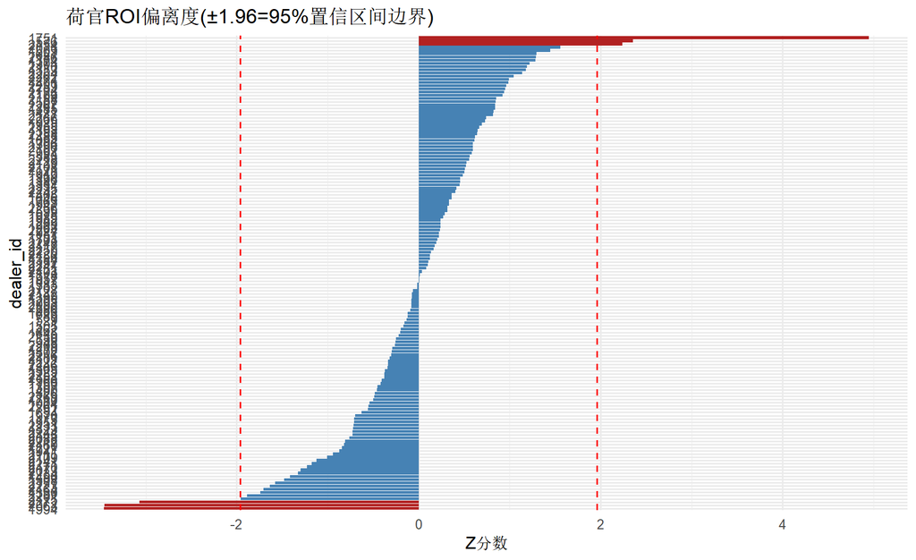

各荷官平均玩家ROI偏离全体均值的Z分数

```r
ggplot(dealer_full, aes(x = reorder(factor(dealer_id), roi_zscore), y = roi_zscore, fill = abs(roi_zscore) > 1.96)) +
  geom_col() +
  geom_hline(yintercept = c(-1.96, 1.96), linetype = "dashed", color = "red") +
  scale_fill_manual(values = c("TRUE" = "firebrick", "FALSE" = "steelblue"), guide = "none") +
  coord_flip() +
  labs(title = "荷官ROI偏离度(±1.96=95%置信区间边界)", x = "dealer_id", y = "Z分数")
```

### 3.1 产品(game_id)维度画像

```r
product_full <- dph[, .(
  记录数 = .N, 总流水 = sum(turnover), 总盈利 = sum(profit),
  平均胜率 = mean(win_rate), 平均玩家ROI = mean(player_roi), 涉及荷官数 = uniqueN(dealer_id)
), by = game_id][order(-总流水)]

product_full |> gt() |>
  fmt_number(columns = c(总流水, 总盈利), decimals = 0) |>
  fmt_number(columns = c(平均胜率, 平均玩家ROI), decimals = 4) |>
  tab_header(title = "按产品(game_id)汇总的地毯式画像")
```

按产品(game_id)汇总的地毯式画像

| game_id | 记录数 | 总流水 | 总盈利 | 平均胜率 | 平均玩家ROI | 涉及荷官数 |
| --- | --- | --- | --- | --- | --- | --- |
| 101 | 77144 | 4,513,773,204 | −594,785,881 | 0.4068 | −0.0943 | 147 |
| 108 | 13601 | 929,340,163 | −31,513,644 | 0.4360 | −0.1116 | 89 |
| 107 | 4342 | 118,053,489 | −1,352,430 | 0.3953 | 0.0668 | 32 |
| 104 | 2047 | 85,316,292 | 2,603,097 | 0.4169 | −0.0987 | 37 |
| 102 | 1987 | 32,912,445 | −4,285,216 | 0.4165 | −0.1432 | 96 |
| 103 | 773 | 11,331,405 | −432,757 | 0.3852 | −0.1491 | 38 |
| 105 | 106 | 125,798 | −20,319 | 0.4418 | −0.1085 | 20 |

## 四、蒙特卡洛模拟验证（后验预测检验 Posterior Predictive Check）

单看一次拟合结果的p值，不足以判断”模型本身是否可信”——**顶级统计规范要求用模拟数据反过来验证模型**：如果模型是对的，用它模拟出的假数据，统计特征应该跟真实数据接近。

[figure not shown]

```r
set.seed(42)
n_sim <- 1000
observed_max <- max(pps$same_round_count)
observed_significant_count <- sum(pps$p_raw < 0.05)

sim_results <- replicate(n_sim, {
  sim_y <- rnbinom(nrow(pps), size = theta, mu = pps$expected_nb)
  sim_p <- 1 - pnbinom(sim_y - 1, size = theta, mu = pps$expected_nb)
  c(max_val = max(sim_y), sig_count = sum(sim_p < 0.05))
})

sim_dt <- data.table(max_val = sim_results["max_val", ], sig_count = sim_results["sig_count", ])

p1 <- ggplot(sim_dt, aes(max_val)) +
  geom_histogram(bins = 30, fill = "grey70", color = "white") +
  geom_vline(xintercept = observed_max, color = "red", linewidth = 1) +
  labs(title = "模拟出的最大同桌局数分布 vs 实际观测值(红线)",
       x = "模拟数据中的最大同桌局数", y = "频数")

p2 <- ggplot(sim_dt, aes(sig_count)) +
  geom_histogram(binwidth = 1, fill = "grey70", color = "white") +
  geom_vline(xintercept = observed_significant_count, color = "red", linewidth = 1) +
  labs(title = "模拟出的\"显著异常搭档数\"分布 vs 实际观测值(红线)",
       x = "模拟数据中p<0.05的搭档数量", y = "频数")

p1 | p2
```

```r
mc_pvalue_max <- mean(sim_dt$max_val >= observed_max)
mc_pvalue_sig <- mean(sim_dt$sig_count >= observed_significant_count)
cat(sprintf("实际最大同桌局数在1000次模拟中的经验p值: %.3f\n", mc_pvalue_max))
```

```
实际最大同桌局数在1000次模拟中的经验p值: 0.000
```

```r
cat(sprintf("实际显著搭档数量在1000次模拟中的经验p值: %.3f\n", mc_pvalue_sig))
```

```
实际显著搭档数量在1000次模拟中的经验p值: 0.000
```

## 五、时序准回测（Quasi-Backtest）：持续性验证

严格意义上的回测需要”已确认的作弊标签”，这里没有，因此改用**持续性检验**作为替代：如果某配对的异常同桌行为是真实的团伙作案，应该在**多个不同小时快照中反复出现**，而不是偶然出现一次。

```r
persistence <- pph[, .(出现次数 = uniqueN(paste(stat_date, stat_hour)),
                         总同桌局数 = sum(same_round_count)), by = .(player_a, player_b)][order(-出现次数)]

datatable(persistence[出现次数 > 1][1:min(20, .N)], options = list(pageLength = 10), rownames = FALSE) |>
  formatStyle("出现次数", background = styleColorBar(range(persistence$出现次数), "#c9e4de"))
```

| player_a | player_b | 出现次数 | 总同桌局数 |
| --- | --- | --- | --- |
| 127516949 | 142668385 | 8 | 55 |
| 143585642 | 150138270 | 7 | 211 |
| 122670041 | 146601345 | 6 | 27 |
| 129921021 | 130850377 | 6 | 17 |
| 144830839 | 148494775 | 6 | 38 |
| 127684170 | 139663204 | 6 | 99 |
| 128092932 | 131024857 | 5 | 17 |
| 130178285 | 138898133 | 5 | 34 |
| 130850377 | 136115317 | 5 | 46 |
| 136115317 | 139554677 | 5 | 45 |

[output cut: 10 more lines]

```r
cat(sprintf("\n仅出现1次的配对占比: %.1f%%（这类更可能是偶发巧合，而非持续性团伙行为）\n",
            mean(persistence$出现次数 == 1) * 100))
```

```
仅出现1次的配对占比: 93.5%（这类更可能是偶发巧合，而非持续性团伙行为）
```

## 七、风控建议与优化措施

| 优先级 | 建议 | 具体措施 |
| --- | --- | --- |
| **高** | 重新按全量数据、更长时间窗口跑本套代码 | 当前样本统计检验力不足是首要瓶颈，扩大样本是提升结论可信度最有效的单一措施 |
| **高** | 建立标签数据回路 | 每次人工复核后的结论（确认/排除）应回写入数据库，为未来真正的监督式回测/机器学习模型积累训练数据 |
| **中** | 引力模型增加协变量 | 加入资金净流向、下注时间同步性等维度，提升模型对”精心设计的团伙作案”的识别能力 |
| **中** | 荷官ROI监控常态化 | 第三节的Z分数排名建议做成每日/每周自动刷新的监控指标，而非一次性报告 |
| **低** | 持续性检验阈值化 | 第五节”出现次数”可设定业务阈值（如≥3次不同小时快照），自动升级为高优先级人工复核对象 |